# Machine Learning Final Project: Melanoma Detection Image Classification

## Isabella Xue

### Outline:

1. Problem Statement
2. Assumptions/Hypotheses about data and model
3. Exploratory Data Analysis
4. Feature Engineering & Transformations
5. Proposed Approach (Model) with checks for overfitting/underfitting & regularization
6. Results (Accuracy) and Learnings from the methodology
7. Future Work

```python
import pandas as pd
```

### Import data using Kaggle **API**

```python
from google.colab import drive
drive.mount('/content/gdrive')
```

```python
from google.colab import files
files.upload()
```

```
Saving kaggle.json to kaggle.json
```

```
{'kaggle.json': b'{"username":"isabellaxue8","key":"ca1eab6e22cefb04162a0e631608314f"}'}
```

```python
!ls -lha kaggle.json
```

```
-rw-r--r-- 1 root root 68 May 25 22:00 kaggle.json
```

```python
!pip install -q kaggle
!mkdir -p ~/.kaggle #Create the directory
!cp kaggle.json ~/.kaggle/
```

```python
!chmod 600 /root/.kaggle/kaggle.json
!pwd #Print Working Directory
```

```
/content
```

```python
!kaggle datasets download -d wanderdust/skin-lesion-analysis-toward-melanoma-detection
#https://www.kaggle.com/datasets/wanderdust/skin-lesion-analysis-toward-melanoma-detection
```

```
Downloading skin-lesion-analysis-toward-melanoma-detection.zip to /content
100% 11.3G/11.3G [08:34<00:00, 27.1MB/s]
100% 11.3G/11.3G [08:34<00:00, 23.6MB/s]
```

```python
!unzip skin-lesion-analysis-toward-melanoma-detection.zip
```

## 1. Problem Statement

Objective: develop a deep learning model for diagnosing melanoma skin cancer using skin lesion images, as distinguishing between seborrheic keratosis, melanoma, and nevus based on visual appearance can be challenging for the general public.

Goal: The goal is to build a robust and reliable deep learning model that can accurately classify skin lesion images, enabling early detection and diagnosis of melanoma, improving patient outcomes, and reducing the need for unnecessary invasive procedures.

Significance: The significance of this project lies in its potential to assist dermatologists and medical professionals in accurately diagnosing skin cancer through automated image analysis. In addition, the proposed solution could be used to help the general public understand their conditions before deciding to see a medical professionals.

## 2. Assumptions/Hypotheses about data and model

Assumptions:

1. The dataset is representative of real-world skin lesion cases and of good quality and resolution, allowing for clear and informative representation of the skin conditions.
2. The model assumes that the training process converges and generalizes well to unseen skin lesion images

Hypotheses:

1. The presence of distinct visual patterns and features in skin lesion images will enable accurate classification within each category
2. Skin lesion images within the same category will exhibit similarities in terms of texture, color, shape, or spatial distribution of lesions
3. The model's performance will be enhanced by leveraging pre-trained CNN architectures which have been trained on large-scale image datasets

## 3. Exploratory Data Analysis

```python
#from pyimagesearch import config
from imutils import paths
import random
import shutil
import os
import numpy as np
import cv2
import matplotlib.pyplot as plt
```

```python
from tensorflow.keras.applications.resnet50 import ResNet50
from tensorflow.python.keras.models import Sequential
from tensorflow.python.keras.layers import Dense
```

#### Use keras ImageGenerator

```python
train_dir = 'skin-lesions/train'
val_dir = 'skin-lesions/valid'
test_dir = 'skin-lesions/test'
batch_size = 32
```

```python
from keras.preprocessing.image import ImageDataGenerator
datagen = ImageDataGenerator(rescale=1 / 150.0)
```

```python
train_generator = datagen.flow_from_directory(
    train_dir,
    target_size=(150, 150),  # Adjust the target size as needed
    color_mode="rgb",
    batch_size=batch_size,
    class_mode='categorical',  # Assuming you have multiple classes
    shuffle=True
)

validation_generator = datagen.flow_from_directory(
    val_dir,
    target_size=(150, 150),
    color_mode="rgb",
    batch_size=batch_size,
    class_mode='categorical',
    shuffle=False
)

test_generator = datagen.flow_from_directory(
    test_dir,
    target_size=(150, 150),
    color_mode="rgb",
    batch_size=batch_size,
    class_mode='categorical',
    shuffle=False  # Set to False for preserving the order of predictions
)
```

```
Found 2000 images belonging to 3 classes.
Found 150 images belonging to 3 classes.
Found 600 images belonging to 3 classes.
```

```python
# Get the list of categories (subdirectories) in the train directory
categories = os.listdir(train_dir)

# Print the number of images in each category
for category in categories:
    category_dir = os.path.join(train_dir, category)
    num_images = len(os.listdir(category_dir))
    print(f"Category: {category}, Number of Images: {num_images}")
```

```
Category: seborrheic_keratosis, Number of Images: 254
Category: melanoma, Number of Images: 374
Category: nevus, Number of Images: 1372
```

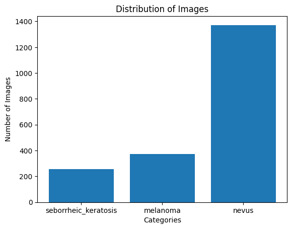

```python
# Plot histograms or bar charts to visualize the distribution of images across different categories
num_images_per_category = []
for category in categories:
    category_dir = os.path.join(train_dir, category)
    num_images = len(os.listdir(category_dir))
    num_images_per_category.append(num_images)

plt.bar(categories, num_images_per_category)
plt.xlabel('Categories')
plt.ylabel('Number of Images')
plt.title('Distribution of Images')
plt.show()
```

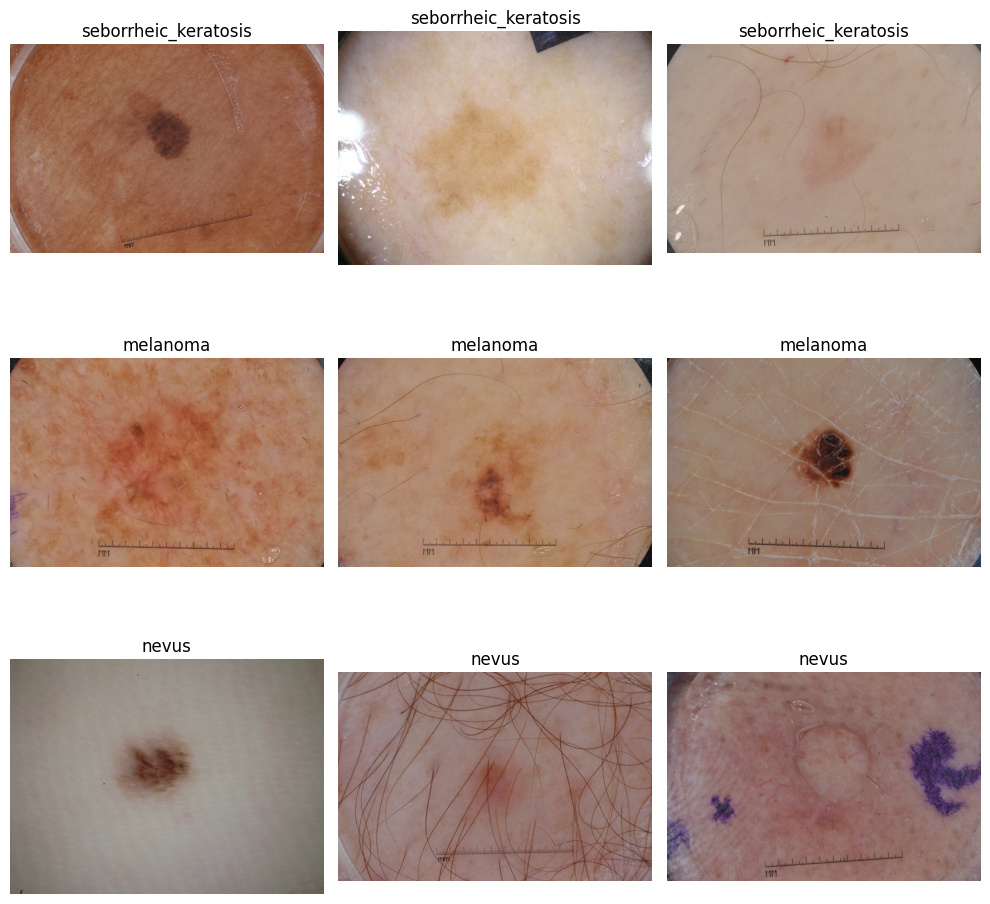

```python
# Display a few sample images from different categories
num_samples_per_category = 3
fig, axs = plt.subplots(len(categories), num_samples_per_category, figsize=(10, 10))
for i, category in enumerate(categories):
    category_dir = os.path.join(train_dir, category)
    image_files = os.listdir(category_dir)[:num_samples_per_category]
    for j, image_file in enumerate(image_files):
        image_path = os.path.join(category_dir, image_file)
        image = cv2.imread(image_path)
        image = cv2.cvtColor(image, cv2.COLOR_BGR2RGB)
        axs[i, j].imshow(image)
        axs[i, j].axis('off')
        axs[i, j].set_title(category)
plt.tight_layout()
plt.savefig('/content/demo_image.png')
```

## 4. Feature Engineering and Transformations

There is class inbalance. Solution: image augmentation

```python
# Initialize ImageDataGenerator with augmentation parameters
datagen = ImageDataGenerator(
    rescale=1./150.0,
    rotation_range=20,  # rotate images randomly within the range of 20 degrees
    width_shift_range=0.2,  # randomly shift images horizontally by 20% of the image width
    height_shift_range=0.2,  # randomly shift images vertically by 20% of the image height
    shear_range=0.2,  # apply shear transformation randomly within the range of 20 degrees
    zoom_range=0.2,  # zoom images randomly by up to 20%
    horizontal_flip=True,  # randomly flip images horizontally
    vertical_flip=True,  # randomly flip images vertically
    fill_mode='nearest'  # use the nearest pixel value for filling in newly created pixels
)

# Generate augmented images and flow from the directory
batch_size = 32
train_generator = datagen.flow_from_directory(
    train_dir,
    target_size=(150, 150),
    batch_size=batch_size,
    class_mode='categorical',
    shuffle=True  # shuffle the images for better training
)
```

```
Found 2000 images belonging to 3 classes.
```

## 5. Proposed Approach (Model) with checks for overfitting/underfitting & regularization

```python
import random as python_random
import tensorflow as tf
import seaborn as sns
import math
from sklearn.metrics import classification_report, confusion_matrix, ConfusionMatrixDisplay

np.random.seed(42)
tf.random.set_seed(42)
```

### ResNet50

```python
from tensorflow.keras.applications.resnet50 import ResNet50
```

```python
# Load the ResNet-50 model
base_model = ResNet50(weights='imagenet', include_top=False, input_shape=(150, 150, 3))

# Freeze the base model's layers
base_model.trainable = False

# Create the model architecture
model_resnet50 = tf.keras.Sequential()
model_resnet50.add(base_model)
model_resnet50.add(tf.keras.layers.GlobalAveragePooling2D())
model_resnet50.add(tf.keras.layers.Dense(256, activation='relu'))
model_resnet50.add(tf.keras.layers.Dropout(0.5))
model_resnet50.add(tf.keras.layers.Dense(3, activation='softmax'))

model_resnet50.compile(loss='categorical_crossentropy', optimizer='adam', metrics=['accuracy'])
```

```
Downloading data from https://storage.googleapis.com/tensorflow/keras-applications/resnet/resnet50_weights_tf_dim_ordering_tf_kernels_notop.h5
```

```python
model_resnet50.summary()
```

```
Model: "sequential"
_________________________________________________________________
 Layer (type)                Output Shape              Param #
=================================================================
 resnet50 (Functional)       (None, 5, 5, 2048)        23587712

 global_average_pooling2d (G  (None, 2048)             0
 lobalAveragePooling2D)

 dense (Dense)               (None, 256)               524544

 dropout (Dropout)           (None, 256)               0

 dense_1 (Dense)             (None, 3)                 771

=================================================================
Total params: 24,113,027
Trainable params: 525,315
Non-trainable params: 23,587,712
_________________________________________________________________
```

#### Fit model

```python
# Train the model
history = model_resnet50.fit(
    train_generator,
    validation_data=validation_generator,
    epochs=10
)
```

## 6. Results (Accuracy) and Learnings from the methodology

```python
#visualize accuracy and loss curve of training and validation
import matplotlib.pyplot as plt
acc = history.history['accuracy']
val_acc = history.history['val_accuracy']
loss = history.history['loss']
val_loss = history.history['val_loss']
```

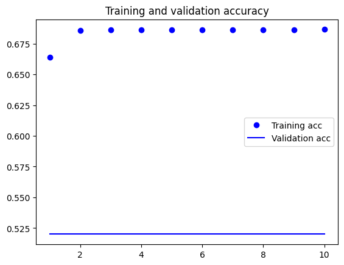

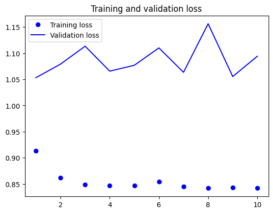

```python
epochs = range(1, len(acc) + 1)
plt.plot(epochs, acc, 'bo', label='Training acc')
plt.plot(epochs, val_acc, 'b', label='Validation acc')
plt.title('Training and validation accuracy')
plt.legend()
plt.figure()

plt.plot(epochs, loss, 'bo', label='Training loss')
plt.plot(epochs, val_loss, 'b', label='Validation loss')
plt.title('Training and validation loss')
plt.legend()
plt.show()
```

```python
test_loss, test_accuracy = model_resnet50.evaluate(test_generator)

print("Test Loss:", test_loss)
print("Test Accuracy:", test_accuracy)
```

```
Test Loss: 0.8767432570457458
Test Accuracy: 0.6549999713897705
```

## 7. Future Work